# Prediction Motivation

David Asare Kumi

July 2, 2019

## About this course

- This course covers the basic ideas behind machine learning/prediction.
1. Study design; training versus test sets.
2. Conceptual issues; out of sample error, ROC curves.
3. Practical implementation; the caret package.
- What this course depends on.
1. The data scientist’s toolbox.
2. R programming.
- What would be useful.
1. Exploratory analysis.
2. Reporting data and reproducible research.
3. Regression models.

## Who Predicts?

- Local government; pension payments.
- Google; whether you will click on an ad.
- Amazon; what movies you will watch.
- Insurance companies; what your risk of death is.
- Johns Hopkins; who will succeed in their programs.

## Why predict?

- Glory; win awards.
- Riches; prize monies on awards.
- For sports; hold competitions for people to predict.
- Save lives; predict to make better medical decisions to save lives.

## A useful book

- The Elements of Statistical Learning.

## A useful package

- The Caret package combines a very large number of predictors.
- Place to get material; machine learning class(coursera).
- Other resources can be obtained from;
1. List of machine learning resources on Quora.
2. List of machine learning resources from science.
3. Advanced notes from MIT open courseware.
4. Advanced notes from CMU.
5. Kaggle; machine learning competitions.

## What is prediction?

- Machine learning deals with what algorithm is the best algorithm to extract data for prediction.

## The Central dogma of prediction

1. Probability/Sampling.
2. Training set.
3. Prediction function.
4. Test set.

## What can go wrong

- The search term.
- The way those terms were used.
- Internet usage may change.

## Components of a predictor

- Question (well defined question).
- Input data.
- Features.
- Algorithm.
- Parameters.
- Evaluation.
- It is important to note that, the components listed above will resolve the issue of “what can go wrong”.

## SPAM Example

- Question; Make it concrete. Can i use quantitative characteristics of the emails to classify them as SPAM/HAM? SPAM; emails that are bulk sent that you may not be interested in. HAM; emails that people will like to receive.
- Input data; spam data set.
- Features; frequency of you = 2/17 = 0.118.
- So now we have quantitative characteristics that we can work with to predict.

```r
library(kernlab)
data(spam)
names(spam)
```

```
##  [1] "make"              "address"           "all"
##  [4] "num3d"             "our"               "over"
##  [7] "remove"            "internet"          "order"
## [10] "mail"              "receive"           "will"
## [13] "people"            "report"            "addresses"
## [16] "free"              "business"          "email"
## [19] "you"               "credit"            "your"
## [22] "font"              "num000"            "money"
## [25] "hp"                "hpl"               "george"
## [28] "num650"            "lab"               "labs"
## [31] "telnet"            "num857"            "data"
## [34] "num415"            "num85"             "technology"
## [37] "num1999"           "parts"             "pm"
## [40] "direct"            "cs"                "meeting"
## [43] "original"          "project"           "re"
## [46] "edu"               "table"             "conference"
## [49] "charSemicolon"     "charRoundbracket"  "charSquarebracket"
## [52] "charExclamation"   "charDollar"        "charHash"
## [55] "capitalAve"        "capitalLong"       "capitalTotal"
## [58] "type"
```

```r
table(spam$type)
```

```
##
## nonspam    spam
##    2788    1813
```

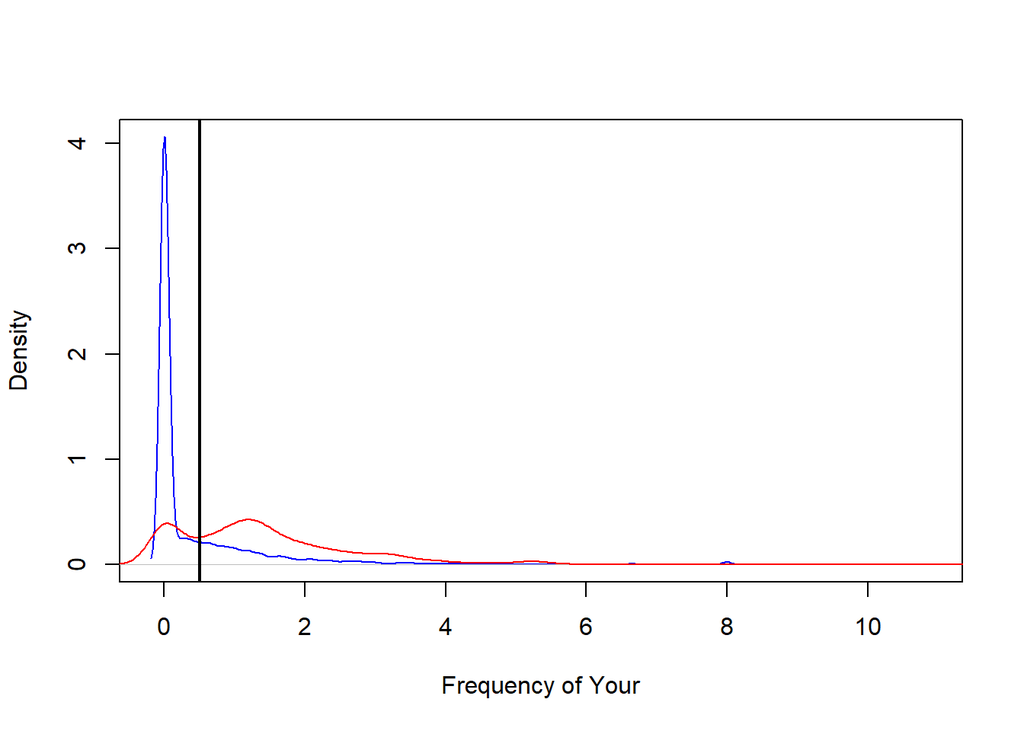

```r
#Let's look at the frequency of your
plot(density(spam$your[spam$type=="nonspam"]),col="blue",main="",xlab="Frequency of Your")
lines(density(spam$your[spam$type=="spam"]),col="red")
#Our algorithm - find a value C where C is a constant(cutoff).If C> 0.5 it is spam.If C< 0.5 it is nonspam.
abline(v=0.5,col="black",lwd=2)
```

```r
#Evaluation
prediction <-ifelse(spam$your>0.5,"spam","nonspam")
table(prediction,spam$type)/length(spam$type)
```

```
##
## prediction   nonspam      spam
##    nonspam 0.4590306 0.1017170
##    spam    0.1469246 0.2923278
```

## Relative importance of steps

- Question; most important.
- Data; followed by collecting data.
- Features; create features.
- Algorithms; finally algorithm.
- An important point; " The combination of some data and an aching desire for an answer does not ensure that a reasonable answer can be extracted from a given body of data“. John Tukey.

## Features matter!

1. Question.
2. Input data.
3. Features.
4. Algorithm.
5. Parameters.
6. Evaluation.

## Properties of good features

- Lead to data compression.
- Retain relevant information.
- Are created based on expert application knowledge.

## Common mistakes

- Trying to automate feature selection.
- Not paying attention to data - specific quirks.
- Throwing away information unnecessarily.

## Issues to consider

- The best machine learning method.
1. Interpretable (to understand it).
2. Simple (easy to explain).
3. Accurate.
4. Fast (to train and test).
5. Scalable; easy to apply to large datasets.

## Prediction is about accuracy tradeoffs

- Interpretability versus accuracy.
- Speed versus accuracy.
- simplicity versus accuracy.
- Scalability versus accuracy.

## Interpretability matters

- Decision trees are very interpretable.
- If statements too.
- You need to understand how the features work.

## Scalability matters

- Accuracy is always the one that gets focused on most.
- Scalability also matters because you must be able to apply your method to large datasets without any problems.

## In and Out sample errors

- In sample error; the error rate you get on the same data set you used to build your predictor. Sometimes called resubstitution error.
- Out of sample error; the error rate you get on a new data set. Sometimes called generalization error.

## Key ideas

- Out of sample error is what you care about.
- In sample error is less than out of sample error.
- The reason is overfitting - matching your algorithm to the data you have. We test on new data.

## Example; In sample error versus out of sample error

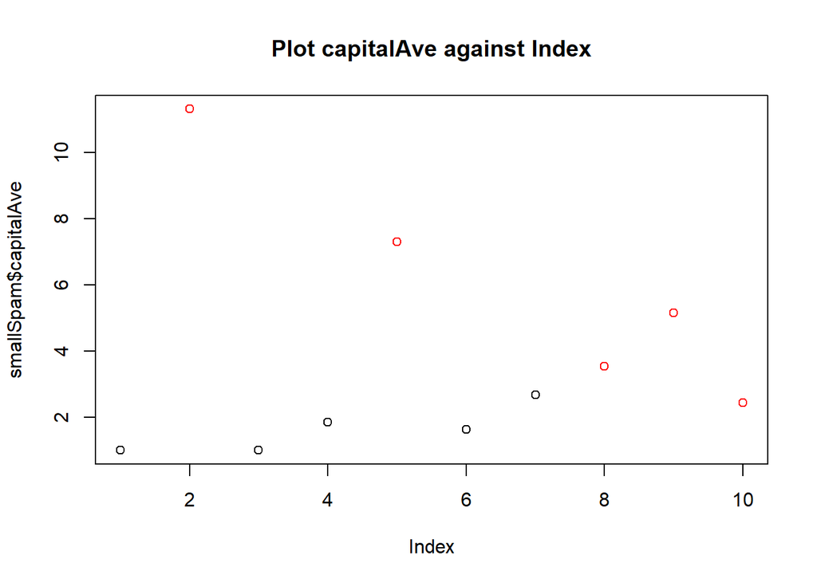

```r
library(kernlab)
data(spam)
set.seed(333)
smallSpam <-spam[sample(dim(spam)[1],size=10),]
spamLabel <-(smallSpam$type=="spam")*1+1
plot(smallSpam$capitalAve,col=spamLabel,main="Plot capitalAve against Index")
```

```r
#Prediction rule1 (Apply rule 1 to smallSpam)
rule1 <-function(x){
  prediction <-rep(NA,length(x))
  prediction[x>2.70] <-"spam"
  prediction[x<2.40] <-"nonspam"
  prediction[x>=2.40 & x<=2.45] <-"spam"
  prediction[(x>2.45 & x<=2.70)] <-"nonspam"
  return(prediction)
}
table(rule1(smallSpam$capitalAve),smallSpam$type)
```

```
##
##           nonspam spam
##   nonspam       5    0
##   spam          0    5
```

```r
#Prediction rule2 (Apply rule 2 to smallSpam)
rule2 <-function(x){
  prediction <-rep(NA,length(x))
  prediction[x>2.8] <-"spam"
  prediction[x<=2.8] <-"nonspam"
  return(prediction)
}
table(rule2(smallSpam$capitalAve),smallSpam$type)
```

```
##
##           nonspam spam
##   nonspam       5    1
##   spam          0    4
```

```r
#Apply to complete spam data
table(rule1(spam$capitalAve),spam$type)
```

```
##
##           nonspam spam
##   nonspam    2141  588
##   spam        647 1225
```

```r
table(rule2(spam$capitalAve),spam$type)
```

```
##
##           nonspam spam
##   nonspam    2224  642
##   spam        564 1171
```

```r
#Look at accuracy
#complicated rule
sum(rule1(spam$capitalAve)==spam$type)
```

```
## [1] 3366
```

```r
#simplified rule (This rule does better than the complicated rule. The reason is overfitting)
sum(rule2(spam$capitalAve)==spam$type)
```

```
## [1] 3395
```

## What’s going on? Overfitting

- Data have two parts; signal and noise. Find the signal and ignore the noise.
- The goal of a predictor is to find signal.
- You can always design a perfect in-sample predictor.
- You capture both signal plus noise when you do that.
- Predictor won’t perform as well on new samples.
- Overfitting; data captures both noise and signal.

## Prediction Study Design

1. Define your error rate (generic error rate).
2. Split data into; Training,Testing and Validation(optional).
3. On the training set pick features.
- Use cross validation.
4. On the training set pick prediction function.
- Use cross validation.
5. If no validation, apply 1 time to test set.
6. If validation,
- Apply to test set and refine.
- Apply 1 time to validation.
7. We build the model using the training data, and apply to the probe dataset.

## Rules of thumb for prediction study design

- If you have a large sample size;
1. 60% training.
2. 20% testing.
3. 20% validation.
- If you have a medium sample size;
1. 60% training.
2. 40% testing.
- If you have a small sample size;
1. Do cross validation.
2. Report caveat of small sample size.

## Some principles to remember

- Set the test/validation set aside and don’t look at it.
- In general, randomly sample training and test.
- Your dataset must reflect structure of the problem.
1. If prediction evolve with time, split train/test in time chunks (called backtesting in finance).
- All subsets should reflect as much diversity as possible.
1. Random assignment does this.
2. You can also try to balance by features but this is tricky.

## Types of errors

- Types of errors that you can make when you are doing a binary prediction problem i.e. when trying to predict things into 1 or 2 groups.

### Basic Terms

- In general, positive = identified and negative = rejected. Therefore,
- True positive = correctly identified.
- False positive= incorrectly identified.
- True negative= correctly rejected.
- False negative= incorrectly rejected.

## Medical testing example

- True positive; sick people correctly diagnosed as sick.
- False positive; healthy people incorrectly identified as sick.
- True negative; healthy people correctly identified as healthy.
- False negative; sick people incorrectly identified as healthy.

## Key quantities

1. Sensitivity = p(positive test/disease) = True Positive (TP).
2. Specificity = p(negative test/no disease) = True Negative (TN).
3. Positive Predictive Value = p(disease /positive test).
4. Negative Predictive Value = p(no disease/negative test).
5. Accuracy = p(correct outcome) = TP + TN.

## Key quantities as fractions

1. Sensitivity = TP / (TP + FN).
2. Specificity = TN / (TN + FP).
3. Positive Predictive Value = TP / (TP + FP).
4. Negative Predictive Value = TN / (TN + FN).
5. Accuracy = (TP + TN) / (TP +TN + FP + FN).

## For continuous data

- We use the mean squared error (MSE) or root mean squared error (RMSE) for easy interpretation. This is the most common error measure for continuous data.

## Common Error Measures

1. Mean Squared Error (or root mean squared error)
- continuous data, sensitive to outliers.
2. Median absolute deviation
- continuous data, often more robust.
3. Sensitivity (recall)
- If you want few missed positives.
4. Specificity
- If you want few negatives called positives.
5. Accuracy
- Weights false positives / negatives equally.
6. Concordance
- One example is Kappa.

## Receiver Operating Characteristics (ROC)

- ROC curves are commonly used to measure the quality of the goodness of a prediction algorithm.

### Why a curve?

- In binary classification, you are predicting one of two categories.
1. Alive / dead.
2. Click on ad / don’t click.
- But your predictions are often quantitative.
1. Probability of being alive.
2. Prediction on a scale from 1 to 10.
- The cutoff you choose gives different results.
- 1- Specificity = Sensitivity.
- The ROC curve tells you about the tradeoffs.
- You can also look at the area under the curve to determine a better prediction algorithm.
1. Area = 0.5 bad.
2. Area < 0.5 worse.
- The higher the area, the better the predictor is.

## Area under the curve (AUC)

- AUC = 0.5; random guessing.
- AUC = 1; perfect classifier.
- In general, AUC of above 0.8 is considered good.

### What is good?

- AUC = 1; perfect classifier i.e. perfect specificity and perfect sensitivity.
- 45 degree line ; specificity = sensitivity.
- Perfect classifier = 1 - specificity.

## Cross Validation

### Study Design

1. Data set.
2. Training data.
3. Test data.
- You apply what ever you get from the training set to the test set.

### Key Idea

1. Accuracy on the training set (resubstitution accuracy) is optimistic.
2. A better estimate comes from an independent set (test set accuracy).
3. But we can’t use the test set when building the model or it becomes part of the training set.
4. So we estimate the test set accuracy with the training set.

### Cross Validation (Approach)

1. Use the training set.
2. Split it into training/test sets.
3. Build a model on the training set.
4. Evaluate on the test.
5. Repeat and average the estimated errors.

### Used for

1. Picking variables to include in a model.
2. Picking the type of prediction function to use.
3. Picking the parameters in the prediction function.
4. Comparing different predictors.
- The different ways people can use training and test set is by;
1. Random subsampling; Do it over and over again and then average the errors.
2. K-folds; Another way is by K - folds.
3. Leave one out; Another approach is leave one out (LOO) cross validation.

### Considerations

- For time series data, data must be used in “chunks”.
- For k-fold cross validation; large k = less bias,more variance and small k = more bias, less variance.
- Random sampling must be done without replacement.
- Random sampling with replacement is the bootstrap;
1. Underestimates of the error.
2. Can be corrected, but it is complicated.
- If you cross validate to pick predictors estimate, you must estimate errors on independent data.

### What data should you use

- Use like data to predict like.
- Weighting the data.

### Key idea

1. To predict X use data related to X.
2. To predict player performance, use data about player.
3. To predict movie preferences, use data about movie preferences.
4. To predict hospitalizations, use data about hospitalizations.